# Connection Score

Jason T. Serviss

2018-07-17

```r
packages <- c(
  "sp.scRNAseq", "sp.scRNAseqData", "printr",
  "ggthemes", "tidyverse"
)
purrr::walk(packages, library, character.only = TRUE)
rm(packages)
```

```r
#DATA
load('~/Github/sp.scRNAseqTesting/inst/testingPoissonSorted/data/uObj.rda')
load('~/Github/sp.scRNAseqTesting/inst/testingPoissonSorted/data/sObj.rda')

#FUNCTIONS
calculateScore <- function(sObj, samples = NULL) {

  if(is.null(samples)) {
    samples <- rownames(swarm)
  }

  swarm <- as.data.frame(t(getData(sObj, "spSwarm")[samples, ]), stringsAsFactors = FALSE)
  costs <- getData(sObj, "costs")
  combos <- as.data.frame(combn(rownames(swarm), 2), stringsAsFactors = FALSE)
  prod <- map(combos, function(x) {
    swarm[x[1], ] * swarm[x[2], ]
  })
  byCost <- map(prod, function(x) x / costs)
  scores <- map_dbl(byCost, sum)
  as.data.frame(t(combos), stringsAsFactors = FALSE) %>%
    as_tibble() %>%
    rename(from = V1, to = V2) %>%
    add_column(score = scores)
}
```

The goal here was to develop a connection score that indicates the strength of the evidence for a connection in the data. This can, hopefully, subsequently be used in permutation tests to give p-value corresponding to the individual detected connections. Due to the fact that deconvolution of permuted data gives rise to high fractions, the score should be regulated by the cost.

To test the scoring function, we utilized the dataset with sorted multiplets. By including an increasing amount of one connection type (multiplets that only have a HCT116-HOS connection) we can evaluate the behavior of the scoring funciton with a known number of connections.

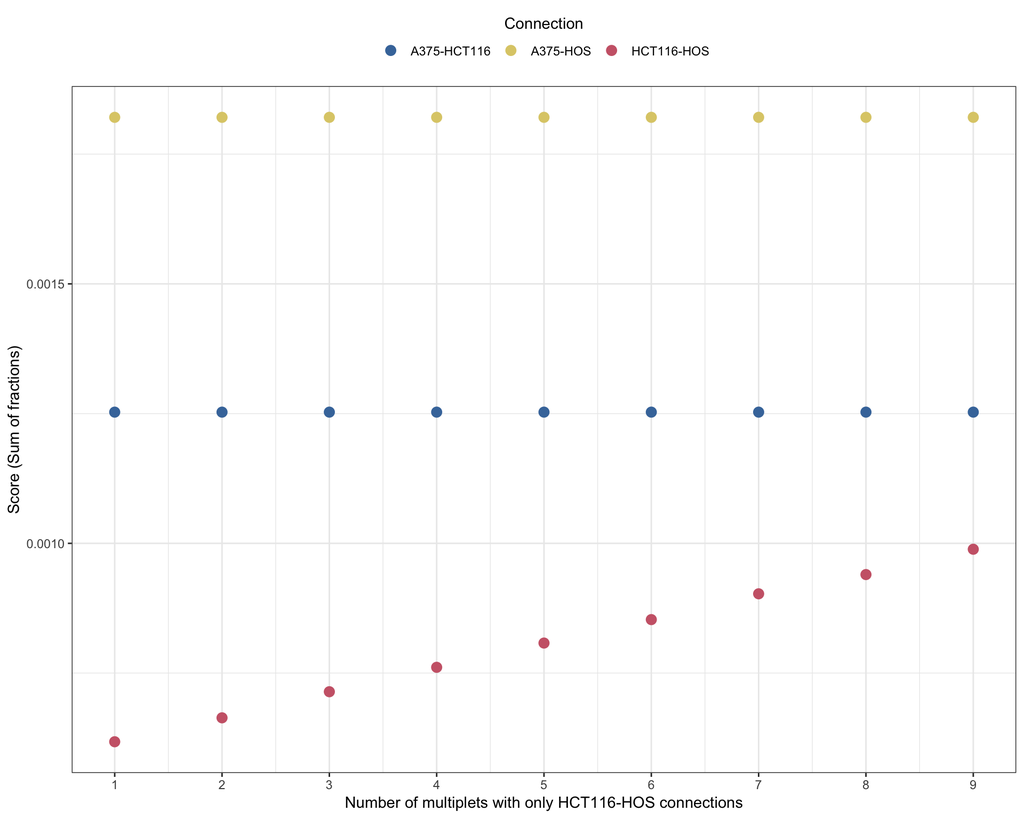

```r
#increase multiplets that ONLY have a HCT116-HOS connection
connectionSamples <- filter(countsSortedMeta2, cellTypes == "HCT116-HOS")$sample
allSamples <- rownames(getData(sObj, "spSwarm"))
otherSamples <- allSamples[!allSamples %in% connectionSamples]

include <- map(2:length(connectionSamples), function(x) {
  c(otherSamples, connectionSamples[1:x])
})
names(include) <- 2:length(connectionSamples)

map_dfr(seq_along(include), function(x) {
  calculateScore(sObj, samples = include[[x]])
}, .id = "realConnections") %>%
  unite(connection, from, to, sep = "-") %>%
  mutate(realConnections = as.numeric(realConnections)) %>%
  ggplot() +
  geom_point(aes(realConnections, score, colour = connection), size = 3) +
  scale_x_continuous(breaks = seq(1, 10, 1)) +
  theme_bw() +
  ggthemes::scale_colour_ptol() +
  labs(x = "Number of multiplets with only HCT116-HOS connections", y = "Score (Sum of fractions)") +
  guides(colour = guide_legend(title = "Connection", title.position = "top", title.hjust = 0.5)) +
  theme(legend.position = "top")
```

The results indicate that adding an increasing amount of HCT116-HOS connections causes an increase in the HCT116-HOS connection score without effecting the scores of the other connections.

Several scoring functions were tested with the results below showing the results of one that exhibited the desired behavior. The scoring function works in the following fashion:

1. The product of the 2 fractions corresponding to the connection being evaluated is calculated for each multiplet. The product was used so that connections with fractions of the type 0, 0.5 will give a product/score of 0.
2. The products for each connection and multiplet are divided by the cost for each multiplet.
3. The sum of these values is calculated for each connection.

So for each connection the following is calculated:

$$Score_{connection} = \sum_{i=1}^{n} \frac{(F_{ct1}\ from\ M_i * F_{ct2}\ from\ M_i)}{Cost\ from\ M_i}$$

Where: *F* = fraction; *ct* = cell type; *M* = multiplet